# Put in your choice of a title

Your Name

Date You Finish

# Getting Started in R

*This exercise was modified from Grayson et al. 2022 https://www.sciencedirect.com/science/article/pii/S0025556422000499, and they modified it from Data Visualization: A Practical Introduction by Kieran Healy https://socviz.co/gettingstarted.html#gettingstarted (Ch. 2).*

Welcome! I’m using a R Markdown document to introduce the free statistical and graphical program R. R Markdown combines sections of text (like this) with sections of code (termed “code chunks”) that do things like calculations, figure generation, etc. The code chunks get executed in R, through the R Studio interface, which you’re working in now. When you finish, you can produce a final “knitted” document that combines text and output from code in a formatted style that is ready to turn in! *(Note: Submit your knitted assignment through the Moodle assignment link.)*

By working through this document, you’ll learn some basics of R, R Studio, and R Markdown. *Make sure to type your answers to questions/completed tasks directly into this document, so they’re included in the final assignment you turn in.*

At the very top of the file is a section of *metadata*, or information about what the file is and what it does. The metadata is delimited by three dashes at the start and another three at the end. If you create your own new R Markdown file in the future, the program automatically sets up the metadata, though you can always edit them later.

**TASK: Change the title, author, and date in the metadata section to your values!** For now, keep the `output` line as it is; it determines the format when you create an exported document (terming “knitting”).

You can type in a Markdown file just like you type text in a word-processing document. Give it a try to answer these questions:

**QUESTION: How much have you done coding or used the R programming language before?**

*Your answer*

**QUESTION: Describe your experience and comfort level with coding or R in the space below.** If you have experience, please tackle the advanced exercises as you work through this handout. If you are new to R, please consult us and your classmates with questions along the way as we develop our skills together!

*Your answer*

## This Document is an RMarkdown File

In R Markdown, **code chunks** are specially delimited sections of the file for code, which runs in R. The green arrow on the chunk’s right will run the code within the chunk in the R console (bottom left corner of the R Studio frame–refer to the handout on R Studio for more about this). You should see the output both in the console and below the code chunk. A few points about code chunks:

- Code chunks start and end with three **`** marks (not single quotation marks, but the bottom of the tilda button under the Esc key).
- Everything in between the start and end marks is R code that will be executed in the console of R Studio.
- Code chunks also must start by identifying the programming language, such as r, in curly brackets (see below); in those brackets, you can also name the chunk or set other options, though it’s not required. If you name chunks, each must have a unique name.
- Use hashtags to comment within code. This is generally best practice for annotating/explaining code, but it should be short. For more extensive comments or commentary, use the text sections of the Markdown file.
- You will gain experience by modifying the code, more and more so through the next few weeks. I will give instructions about those tasks in the (white) text areas.

```r
# This is your first code chunk
# You can include text within code chunks, but you need a hashtag before it--this tells R to ignore it (i.e., it's not code)

# R can do math:
2+2
```

```
## [1] 4
```

```r
# But many R commands use functions, like these simple ones:
sqrt(10)
```

```
## [1] 3.162278
```

```r
print("R code is cool")
```

```
## [1] "R code is cool"
```

```r
# When you click the run arrow, the output should appear below the chunk and in the RStudio Console
```

You can add your own chunk by moving the cursor to a blank line and choosing Code > Insert Chunk from the RStudio menu, or clicking the green square with the white C and the + sign in the bar then selecting R. When you do either of these, an empty chunk will appear in your file. You can also type 3 **`**, add your code, then close with another 3 **`**.

**TASK: Create your own code chunk in the blank lines below.** Write some example code similar to the first chunk above (or any code that know that you would like to include).

## EXPORTING your Markdown file

When you click the **Knit** button at the top (with the blue ball of yarn icon), it will generate a document that includes both content as well as the output of any embedded R code chunks within the document (unless you exclude it from the document, like the next setup code chunk below). Save your R Markdown (Rmd) file (click the disc icon in the top left, or Ctrl S) and try it out now! Note that you’ll knit again at the end when you finish to generate your final output to turn in.

**ADVANCED options**: Learn about customizing the appearance of code chunks in Markdown: https://r4ds.had.co.nz/r-markdown.html#code-chunks

The open source book “R for Data Science” is the fundamental R skills book by Hadley Wickham (Chief Scientist at RStudio) and Garrett Grolemund (Principal Data Science Educator at RStudio) https://r4ds.had.co.nz/ Check out section 27.4.2 and try out some of the display options in your practice chunk (*again, optional for those who are experienced using R*)

## Load Libraries

Packages are sets of code (and sometimes data) that others have written to make it easier to carry out certain analyses in R–like making a figure or calculating summary statistics. They are kind of like apps on a device. To use them, you first have to install them (like downloading an app), which adds them to your directory, or library, in R. Then you have to load them (like opening the app). You only have to install packages once; after that, you only need to load them from your library when you start a session in R. You can install packages from the “Packages” tab in the “Files” frame in the bottom right corner of R Studio; you can also type the command `install("name of package")` in the console. (Note the quotation marks!)

To use installed packages, we use the command `library(name of package)`. Without this step, R will not be able to find the functions contained in these packages. The best practice is to load (using library commands) all the packages we need in a first code chunk at the top of the R Markdown document, or at the start of an R script if you’re working in that platform.

## A few fundmental things to know about R

### Everything is an object

The R coding language is based on objects. These can take many forms, but often include data that can be numbers, words/characters, lists, or even data tables. They can also be output from analyses (e.g., a figure or results from a statistical test). You can directly type objects into R, import them from other files such as a spreadsheet, or generate them using code. Assign a name to objects using a left-facing “arrow” as in: Name <- data. After you name an object, you can refer to it later, and R will use whatever is to the right of the arrow when carrying out a function. *Hint: Make names short, and avoid any R code terms such as mean* Note: You can see the active objects in the environment window on the top right of your screen

```r
c(1, 2, 3, 1, 3, 5, 25)
```

```
## [1]  1  2  3  1  3  5 25
```

```r
# c() combines values into a vector, an example of an R object
# These should print below

my_numbers <- c(1, 2, 3, 1, 3, 5, 25)
#

your_numbers <- c(5, 31, 71, 1, 3, 21, 6)
#
```

Run the code chunk below (click the right green arrow button) and annotate the code with what it does.

```r
my_numbers
```

```
## [1]  1  2  3  1  3  5 25
```

```r
#
```

### Do things in R using functions

A function’s arguments are the things the function needs to know in order to do something.

```r
# functions need arguments
mean()

# The Markdown file will not knit with an error in the code, but we wanted to demonstrate
# getting an error. Thus this chunk has eval = FALSE in the header to display the code but
# suppress running the chunk or displaying the output
```

**QUESTION:** Why do you get an error? How do you find out what arguments the mean function needs? (You will fix it in the next code chunk) *Hint: run this chunk and look at the output in the console pane or above–it will give you information about the error.*

*Your answer:*

**TASK: Follow the example below to add code to the chunk that will calculate the mean of the object your_numbers**

```r
mean(x = my_numbers)
```

```
## [1] 5.714286
```

```r
# While the function arguments have names that are used internally, (here x),
# you don’t strictly need to specify the name for the function to work, as the next line shows.

mean(my_numbers)
```

```
## [1] 5.714286
```

```r
# below add code to calculate the mean of your_numbers
```

Let’s try another function: `summary()`

```r
summary(my_numbers)
```

```
##    Min. 1st Qu.  Median    Mean 3rd Qu.    Max.
##   1.000   1.500   3.000   5.714   4.000  25.000
```

```r
# You can also assign results to an object
my_summary <- summary(my_numbers)

# Then you can "call" the summary by just typing the name:
my_summary
```

```
##    Min. 1st Qu.  Median    Mean 3rd Qu.    Max.
##   1.000   1.500   3.000   5.714   4.000  25.000
```

**QUESTION:** Run the code in the chunk aboven. Based on the output, what does this function (`summary`) do?

*Your answer*

### Functions come in libraries

Functions from libraries are “pre-coded” to perform tasks without writing commands from scratch.

**TASK: Run the code, then add annotations next to the hashtags in the code chunk to note what each of these functions doing:**

```r
table(my_numbers)
```

```
## my_numbers
##  1  2  3  5 25
##  2  1  2  1  1
```

```r
#

sd(my_numbers)
```

```
## [1] 8.616153
```

```r
#
```

### If you’re not sure what an object is, ask for its class

The code chunk below gives some examples for doing this. Run it to see what the output looks like.

```r
class(my_numbers)
```

```
## [1] "numeric"
```

```r
class(my_summary)
```

```
## [1] "summaryDefault" "table"
```

```r
class(summary)
```

```
## [1] "function"
```

Objects can change class based on the inputs:

```r
my_new_vector <- c(my_numbers, "Apple")
```

**TASK: In the space below, create your own code chunk that answers these questions**

**QUESTION: How do you look at the information in your new object `my_new_vector`?** Hint: review the code chunk called print your object.)

*Your answer:*

**QUESTION: What data class does your new object contain?**

*Your answer:*

### Using Datasets

Some libraries have data files associated with the package of functions. The socviz library has a small dataframe called “titanic.” Let’s look at it:

```r
titanic
```

```
##       fate    sex    n percent
## 1 perished   male 1364    62.0
## 2 perished female  126     5.7
## 3 survived   male  367    16.7
## 4 survived female  344    15.6
```

```r
class(titanic)
```

```
## [1] "data.frame"
```

You can call just a portion of the data using the $ to designate a column. Let’s try it:

```r
titanic$percent
```

```
## [1] 62.0  5.7 16.7 15.6
```

**TASK: How would you select the sample size (n) column in the titanic dataset?** Create your own code chunk below to return the values in the “n” column. Remember to include the {r} line.

The tidyverse uses an augmented version of a data frame called a tibble. Tibbles have some features that can become important. For example, on its own it will never change the name of variable, or the type of input (e.g., from factor to character). Let’s make R treat the previous dataframe as a tibble:

```r
titanic_tb <- as_tibble(titanic) #"as_tibble" makes R treat the data frame as a tibble
titanic_tb
```

```
## # A tibble: 4 × 4
##   fate     sex        n percent
##   <fct>    <fct>  <dbl>   <dbl>
## 1 perished male    1364    62
## 2 perished female   126     5.7
## 3 survived male     367    16.7
## 4 survived female   344    15.6
```

**QUESTION:** What differences (if any) do you see in the data frame vs. the tibble in this example?

*Your answer:*

**Introduction to graphing with R** R is does an amazing job with figures. We’ll focus on using the function `ggplot` to make figures. For now, just follow the code I provide. Later I’ll show you ways to build and customize your own figures.

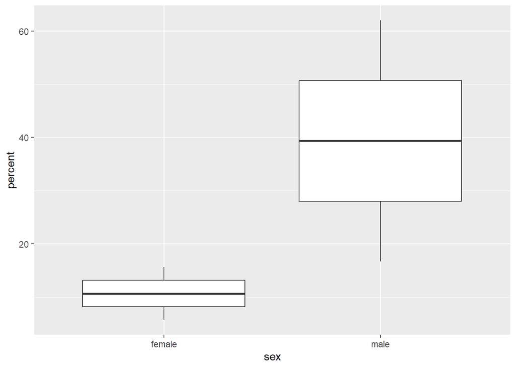

```r
ggplot(titanic_tb, aes(x = sex, y = percent)) + #this line identifies the data set, x, and y variables)
  geom_boxplot() #this line says how to graph the data
```

## This is important! Be patient with R, and with yourself

Here are three very specific things to watch out for when writing R code:

- Make sure parentheses are balanced and that every opening “`(`” has a corresponding closing “`)`”.
- Make sure you complete your expressions. If you think you have completed typing your code, but instead of seeing the `>` command prompt at the console you see the `+` character instead, that may mean R thinks you haven’t written a complete expression yet. You can hit `Esc` or `Ctrl-C` to force your way back to the console and try typing your code again.
- In ggplot specifically, as you will see, we will build up plots a piece at a time by adding expressions to one another. When doing this, make sure your `+` character goes at the end of the line, and not the beginning. That is, write this:

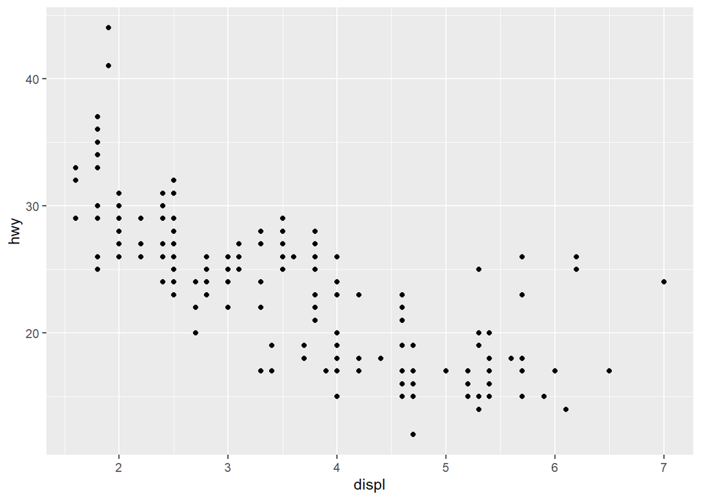

```r
ggplot(data = mpg, aes(x = displ, y = hwy)) +
    geom_point()
```

and not this:

```r
ggplot(data = mpg, aes(x = displ, y = hwy))
+ geom_point()

# What do you need to fix here? Change it to be correct!
# Note: Our header includes echo=TRUE [show the code], eval=FALSE [don't run the code]
# for the knitted output document since we know there is an error. Leave
# this header so your fixed code prints in the output file, but not a duplicate of the graph
```

## Some more common & important skills

### Get data into R

To practice more with R and graphing, we are going to use a dataset collected by Pacific students about caterpillars eating kale plants. We’ll call the file kale. I’ve saved a .csv file (this is the best format for importing data), and we’ll import it from github. Later, I’ll show you how to import your own data sets.

```r
#to above add eval = FALSE if data preloaded

url <- "https://raw.githubusercontent.com/slhalpern/PUEcology-course/refs/heads/main/REU_2021.csv"

kale <- read_csv(file = url)
```

## Summarizing data in various ways

Let’s start by practicing something you’ve already done using the data you imported. We’ll look at the variable RGR, or relative growth rate, a measure of how fast an organism grows measured as g/g/day.

**Task: I’ve started a code chunk below. Add code to it that will summarize the variable RGR.** *Hints: Return to the titanic data to remember how to select a specific column. Make sure you have the names of the columns correct, lowercase and uppercase characters matter in variable names.*

```r
kale #remind yourself what this code does! It's OK to run the chunk to see what happens.
```

```
## # A tibble: 189 × 7
##    Temporal_Rep Mvmt_Trt Fertilizer_Trt Leaf_Num Longest_Lf Avg_Lf_Dam     RGR
##           <dbl> <chr>    <chr>             <dbl>      <dbl>      <dbl>   <dbl>
##  1            1 N        N                     4       6             0 -0.405
##  2            1 N        N                     3       5.95          0 -0.102
##  3            1 N        N                     4       5.75          0 -0.0757
##  4            1 N        N                     4       5.58          0 -0.165
##  5            1 N        N                     4       7.5           0 -0.129
##  6            1 N        N                     4       6             0 -0.321
##  7            1 N        N                     3       5.5           0 -0.139
##  8            1 N        N                     4       6.3           0 -0.0564
##  9            1 N        N                     4       6.4           0 -0.113
## 10            1 N        N                     4       5.8           0 -0.0700
## # ℹ 179 more rows
```

```r
#delete this comment and add code to summarize RGR here!
```

**QUESTION:** What is the average RGR? What is the range of values for RGR?

*Your answer:*

### Summarizing data by groups

In biology, we’re often interested in calculating central tendency and spread variables by groups–e.g., comparing a treatment and a control group. We can do that in the `tidyverse` by using `group_by`. In the kale data set, groups include:

- Temporal_Rep (week of the trial)
- Mvmt_Trt (whether larvae could move between plants), and
- Fertilizer_Trt (whether plants were fertilized or not).

The code below shows how to summarize a variable by group.

```r
kale |> #|> tells R to take the output of this line and pass it to the next line of code--it's called a pipe
  group_by(Fertilizer_Trt) |> # this groups data by fertilizer treatment. Note the pipe again!
  summarize(avg.RGR = mean(RGR, na.rm = TRUE)) #na.rm = TRUE tells R to ignore any missing values, which are coded as NA in the data table
```

```
## # A tibble: 2 × 2
##   Fertilizer_Trt avg.RGR
##   <chr>            <dbl>
## 1 N                0.283
## 2 Y                0.245
```

**Question:** Is RGR faster or slower in fertilized kale plants compared to unfertilized ones?

*Your answer:*

**Task** Add code to the chunk above (or add a new chunk below) to calculate average RGR for one of the other sets of groups. Rerun the chunk and answer the questions below.

**Questions:**

What grouping variable did you choose? *Your answer:*

Is your variable larger or smaller in fertilized plants compared to unfertilized plants? *Your answer:*

Does the effect of fertilizer on your variable makes sense? Briefly (in a sentence or so) explain your reasoning. *Your answer:*

We might want to calculate more than just the mean for groups. For example, we might want to know how many observations are in each group (`length` counts this), the standard deviation for each group (`sd`), the variance for each group (`var`), the smallest (`min`) and largest (`max`) value for each group, or the median for each group (`median`).

**Task: Cut and paste the code chunk above, then modify it to calculate these different variables.** Hint: If you want to see them all in one table, put a comma in between the last 2 parentheses in the `summarize` line of code, hit return, add the next variable (be sure to name it before the = sign!), and repeat. *Note: Do NOT use na.rm = TRUE for length*

```r
kale |>
  group_by(Fertilizer_Trt) |>
  summarize(avg.RGR = mean(RGR, na.rm = TRUE),
            n.RGR = length(RGR),
            sd.rgr = sd(RGR, na.rm = TRUE),
            var.rgr = var(RGR, na.rm = TRUE),
            min.rgr = min(RGR, na.rm = TRUE),
            max.rgr = max(RGR, na.rm = TRUE),
            median.rgr = median(RGR, na.rm = TRUE))
```

```
## # A tibble: 2 × 8
##   Fertilizer_Trt avg.RGR n.RGR sd.rgr var.rgr min.rgr max.rgr median.rgr
##   <chr>            <dbl> <int>  <dbl>   <dbl>   <dbl>   <dbl>      <dbl>
## 1 N                0.283    87  0.420   0.176  -1.49     1.85      0.312
## 2 Y                0.245   102  0.393   0.154  -0.793    1.49      0.273
```

## Make a figure

We will now use the kale data to make two figures using `ggplot`. I will walk you through the first one, then you will make subsequent ones more independently. Keep this file handy as a model for code you’ll need later!

We’ll start by making a histogram of the rgr data.

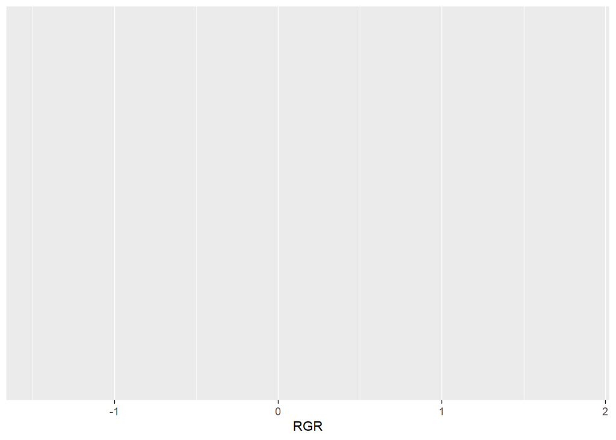

```r
ggplot(data = kale, aes(x = RGR))
```

```r
# Put the name of your data file after data =
# aes (short for aesthetic) tells R about the variables you'll use in the plot--here it's just one because it's a histogram
# information for aes always goes inside parentheses; if there is more than one piece of information, they are separated by commas

# Watch your parentheses! One of the most common errors is missing closing one!
```

Why is the graph blank? We need to add a geom, which tells R what kind of graph to make! **TASK** Copy the code above, then add `geom_histogram()` to your code using the plus sign at the end of the first line (with the geom on the 2nd line). *Note: Often you will see ggplot code written with each argument on a different line to make it easier to follow; again, each line ENDS with a + sign, which tells R to add the next line to the figure being built.*

**QUESTION:** Describe the histogram you created–it’s shape, distribution of the data, etc.

*Your answer:*

**ADVANCED:** If you have used R and ggplot before, or just want to explore it, try changing the bin width or number of bins, the orientation (horizontal vs. vertical), or something else you want to play with. https://ggplot2.tidyverse.org/reference/geom_histogram.html has information on the code.

**TASK: make a boxplot, using geom_boxplot** Boxplots are some of the most useful figures in ecology because they provide a lot of information about the data. Practice them by making a boxplot for rgr separated by the grouping variable of fertilizer treatment. I provide the code this time; in the future, use this code as a model to make your own boxplots.

**ADVANCED:** If you have used R and ggplot before, or just want to explore it, try changing the color, scale, or some other display feature of the boxplot. See this guide for examples of changes you can make to boxplots, and the code to do so: https://www.sthda.com/english/wiki/ggplot2-box-plot-quick-start-guide-r-software-and-data-visualization

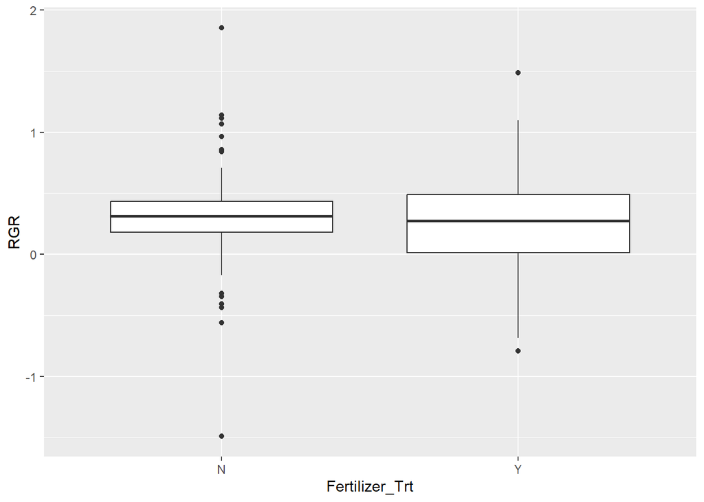

```r
ggplot(kale, aes(Fertilizer_Trt, RGR)) +
  geom_boxplot()
```

```r
# Note for the first line of code: R assumes x variable is first, then y.
# You can also explicitly identify them in the code--e.g., x = Fertilizer_Trt, y = RGR
# These two formats are equivalent.
```

**QUESTION:** Describe the boxplot you created, including information about both the central tendency and the spread.

*Your answer:*

Congrats! You have navigated through your first R Markdown file and run the code to produce a figure! Next time we’ll make more exploratory figures, and start to carry out statistical analyses.